# EXAMEN PRÁCTICO MÓDULO 1

Yulia Frenkel

28 02 2020

## Vectores

1. Cree el vector A utilizando la función seq, de tal modo que se obtenga el siguiente resultado: 10, 8, 6, 4, 2, 0, -2, -4, -6. ¿Qué longitud tiene este vector? ¿Cuál es su suma? ¿Cuál es su valor medio? ¿Cuál es su error típico? El error típico se obtiene dividiendo la desviación típica entre la raíz cuadrada del tamaño de la muestra (número de elementos).

```r
A <-seq(10,-6,-2)
A
```

```
## [1] 10  8  6  4  2  0 -2 -4 -6
```

```r
n<-length(A)
n
```

```
## [1] 9
```

```r
sum(A)
```

```
## [1] 18
```

```r
mean(A)
```

```
## [1] 2
```

```r
error <- sd(A)/sqrt(n)
error
```

```
## [1] 1.825742
```

2. Utilizando las funciones rep y seq, cree el vector B, con los siguientes datos: 0, 0, 0, 0, 0, 1, 2.5, 4, 5.5. Calcule: la suma de A y B, la diferencia entre A y B, $\sqrt {A^{2}+B^{2}}$

```r
B <-c(rep(0,5),seq(1,5.5,1.5))
B
```

```
## [1] 0.0 0.0 0.0 0.0 0.0 1.0 2.5 4.0 5.5
```

```r
A+B
```

```
## [1] 10.0  8.0  6.0  4.0  2.0  1.0  0.5  0.0 -0.5
```

```r
A-B
```

```
## [1]  10.0   8.0   6.0   4.0   2.0  -1.0  -4.5  -8.0 -11.5
```

```r
sqrt(A^2+B^2)
```

```
## [1] 10.000000  8.000000  6.000000  4.000000  2.000000  1.000000  3.201562
## [8]  5.656854  8.139410
```

## Matrices

Se dispone de la siguiente tabla de datos:

| PESO | ESTATURA | EDAD |
| --- | --- | --- |
| 74 | 1.68 | 22 |
| 85 | 1.83 | 25 |
| 58 | 1.58 | 21 |
| 80 | 1.72 | 20 |

3.Cree la matriz M con estos datos, indicando el nombre de cada columna. Muestre la dimensión de la matriz. Utilizando la función apply, obtenga un promedio de los resultados por columna.

```r
peso <-c(74,85,58,80)
estatura <-c(1.68,1.83,1.58,1.72)
edad <-c(22,25,21,20)
m <-cbind(peso,estatura,edad)
m
```

```
##      peso estatura edad
## [1,]   74     1.68   22
## [2,]   85     1.83   25
## [3,]   58     1.58   21
## [4,]   80     1.72   20
```

```r
dim(m)
```

```
## [1] 4 3
```

```r
apply(m,2, mean)
```

```
##     peso estatura     edad
##  74.2500   1.7025  22.0000
```

## Dataframes

4.Con los datos de la matriz anterior, cree el dataframe datos. Añada dos columnas, con el nombre de los individuos: “Pedro”, “José”, “María”, “Javier”; y el sexo: “Hombre” y “Mujer”. Añada un nuevo individuo al conjunto de datos: “Ana”, peso=70, estatura=1.72 y edad=24. La variable nombre es de tipo carácter, sexo es un factor y el resto son numéricas. Muestre la estructura del dataframe datos.

```r
datos <-data.frame(m)
nombre <-c("Pedro", "José", "María", "Javier")
sexo <-c("Hombre", "Hombre","Mujer", "Hombre")
datos <-data.frame( nombre, sexo, datos,stringsAsFactors = FALSE)
datos$sexo =factor(sexo)
datos
```

```
##   nombre   sexo peso estatura edad
## 1  Pedro Hombre   74     1.68   22
## 2   Jose Hombre   85     1.83   25
## 3  Maria  Mujer   58     1.58   21
## 4 Javier Hombre   80     1.72   20
```

```r
datos <-rbind (datos,list("Ana", "Mujer",70, 1.72, 24))
datos
```

```
##   nombre   sexo peso estatura edad
## 1  Pedro Hombre   74     1.68   22
## 2   Jose Hombre   85     1.83   25
## 3  Maria  Mujer   58     1.58   21
## 4 Javier Hombre   80     1.72   20
## 5    Ana  Mujer   70     1.72   24
```

```r
str(datos)
```

```
## 'data.frame':    5 obs. of  5 variables:
##  $ nombre  : chr  "Pedro" "Jose" "Maria" "Javier" ...
##  $ sexo    : Factor w/ 2 levels "Hombre","Mujer": 1 1 2 1 2
##  $ peso    : num  74 85 58 80 70
##  $ estatura: num  1.68 1.83 1.58 1.72 1.72
##  $ edad    : num  22 25 21 20 24
```

5.Del dataframe creado, extraiga: el peso de Ana, todos los nombres y los datos de Javier. Añada una columna al dataframe datos, denominada ALTURA. De tal modo que, si el individuo mide más 1.78, tendrá el valor “Alto”; y de lo contrario, tendrá el valor “Normal”.

```r
datos$peso[5]
```

```
## [1] 70
```

```r
datos$nombre
```

```
## [1] "Pedro"  "Jose"   "Maria"  "Javier" "Ana"
```

```r
datos[datos$nombre == "Javier",]
```

```
##   nombre   sexo peso estatura edad
## 4 Javier Hombre   80     1.72   20
```

```r
datos$ALTURA=ifelse(datos$estatura>1.78,"Alto","Normal")
datos
```

```
##   nombre   sexo peso estatura edad ALTURA
## 1  Pedro Hombre   74     1.68   22 Normal
## 2   Jose Hombre   85     1.83   25   Alto
## 3  Maria  Mujer   58     1.58   21 Normal
## 4 Javier Hombre   80     1.72   20 Normal
## 5    Ana  Mujer   70     1.72   24 Normal
```

## Listas

6. Cree la lista L, con todos los objetos que ha creado. Encuentre en la lista, los valores de A que cumplen la condición A+2<0, el valor [3,2] de la matriz M, y los datos de Ana del dataframe datos.

```r
L=list(A=A,B=B,m=m,datos=datos)
L
```

```
## $A
## [1] 10  8  6  4  2  0 -2 -4 -6
##
## $B
## [1] 0.0 0.0 0.0 0.0 0.0 1.0 2.5 4.0 5.5
##
## $m
##      peso estatura edad
## [1,]   74     1.68   22
## [2,]   85     1.83   25
## [3,]   58     1.58   21
## [4,]   80     1.72   20
##
## $datos
##   nombre   sexo peso estatura edad ALTURA
## 1  Pedro Hombre   74     1.68   22 Normal
## 2   Jose Hombre   85     1.83   25   Alto
## 3  Maria  Mujer   58     1.58   21 Normal
## 4 Javier Hombre   80     1.72   20 Normal
## 5    Ana  Mujer   70     1.72   24 Normal
```

```r
L$A[A+2<0]
```

```
## [1] -4 -6
```

```r
L$m[3,2]
```

```
## estatura
##     1.58
```

```r
L$datos[datos$nombre == "Ana",]
```

```
##   nombre  sexo peso estatura edad ALTURA
## 5    Ana Mujer   70     1.72   24 Normal
```

## Funciones y Bucles

7. Cree la función normalizar, que realice la normalización estándar (restar la media y dividir por el error típico) y la normalización min-max (restar el mínimo y dividir por la diferencia entre el máximo y el mínimo). Dicha función devolverá una lista. Utilice esta función empleando como argumento el PESO del dataframe datos, y después empleando la ESTATURA.

```r
normalizar <- function(x){

  std_norm_x <- (x - mean(x)) / sd(x) / sqrt(length(x))
  min_max_norm_x <- (x - min(x)) / (max(x) - min(x))

  return(list(standart = std_norm_x, min_max = min_max_norm_x))
}

print(normalizar(datos$peso))
```

```
## $standart
## [1]  0.02596454  0.50198109 -0.66642318  0.28560993 -0.14713239
##
## $min_max
## [1] 0.5925926 1.0000000 0.0000000 0.8148148 0.4444444
```

```r
print(normalizar(datos$estatura))
```

```
## $standart
## [1] -0.1293548  0.6169231 -0.6268734  0.0696526  0.0696526
##
## $min_max
## [1] 0.40 1.00 0.00 0.56 0.56
```

8. Mediante un bucle for, cree un vector que contenga los primeros 100 elementos de la siguiente sucesión numérica: $\frac{1}{2}+\frac{1}{4}+\frac{1}{8}+\frac{1}{16}+\frac{1}{32}$ ¿Cuál es su suma?

Para resolver el ejercicio, tenga en cuenta lo siguiente: $\frac{1}{2}+\frac{1}{2^{2}}+\frac{1}{2^{3}}+\frac{1}{2^{4}}+\frac{1}{2^{5}}$

```r
i<-1:100
for (val in i) {
   v <-1/(2^i)
}
v
```

```
##   [1] 5.000000e-01 2.500000e-01 1.250000e-01 6.250000e-02 3.125000e-02
##   [6] 1.562500e-02 7.812500e-03 3.906250e-03 1.953125e-03 9.765625e-04
##  [11] 4.882812e-04 2.441406e-04 1.220703e-04 6.103516e-05 3.051758e-05
##  [16] 1.525879e-05 7.629395e-06 3.814697e-06 1.907349e-06 9.536743e-07
##  [21] 4.768372e-07 2.384186e-07 1.192093e-07 5.960464e-08 2.980232e-08
##  [26] 1.490116e-08 7.450581e-09 3.725290e-09 1.862645e-09 9.313226e-10
##  [31] 4.656613e-10 2.328306e-10 1.164153e-10 5.820766e-11 2.910383e-11
##  [36] 1.455192e-11 7.275958e-12 3.637979e-12 1.818989e-12 9.094947e-13
##  [41] 4.547474e-13 2.273737e-13 1.136868e-13 5.684342e-14 2.842171e-14
##  [46] 1.421085e-14 7.105427e-15 3.552714e-15 1.776357e-15 8.881784e-16
##  [51] 4.440892e-16 2.220446e-16 1.110223e-16 5.551115e-17 2.775558e-17
##  [56] 1.387779e-17 6.938894e-18 3.469447e-18 1.734723e-18 8.673617e-19
##  [61] 4.336809e-19 2.168404e-19 1.084202e-19 5.421011e-20 2.710505e-20
##  [66] 1.355253e-20 6.776264e-21 3.388132e-21 1.694066e-21 8.470329e-22
##  [71] 4.235165e-22 2.117582e-22 1.058791e-22 5.293956e-23 2.646978e-23
##  [76] 1.323489e-23 6.617445e-24 3.308722e-24 1.654361e-24 8.271806e-25
##  [81] 4.135903e-25 2.067952e-25 1.033976e-25 5.169879e-26 2.584939e-26
##  [86] 1.292470e-26 6.462349e-27 3.231174e-27 1.615587e-27 8.077936e-28
##  [91] 4.038968e-28 2.019484e-28 1.009742e-28 5.048710e-29 2.524355e-29
##  [96] 1.262177e-29 6.310887e-30 3.155444e-30 1.577722e-30 7.888609e-31
```

```r
sum(v)
```

```
## [1] 1
```

## Dataframes y Gráficos

En los siguientes ejercicios trabajará con el dataset mtcars, que consta de 32 coches y 11 variables. Descripción de las variables que se van a utilizar:

mpg: Millas recorridas por galón de combustible. cyl: Número de cilindros. hp: Caballos de fuerza. wt: Peso (1000 libras). qsec: Tiempo empleado en recorrer 1/4 de milla (segundos).

```r
library(car)
df<-data.frame(mtcars)
str(df)
```

```
## 'data.frame':    32 obs. of  11 variables:
##  $ mpg : num  21 21 22.8 21.4 18.7 18.1 14.3 24.4 22.8 19.2 ...
##  $ cyl : num  6 6 4 6 8 6 8 4 4 6 ...
##  $ disp: num  160 160 108 258 360 ...
##  $ hp  : num  110 110 93 110 175 105 245 62 95 123 ...
##  $ drat: num  3.9 3.9 3.85 3.08 3.15 2.76 3.21 3.69 3.92 3.92 ...
##  $ wt  : num  2.62 2.88 2.32 3.21 3.44 ...
##  $ qsec: num  16.5 17 18.6 19.4 17 ...
##  $ vs  : num  0 0 1 1 0 1 0 1 1 1 ...
##  $ am  : num  1 1 1 0 0 0 0 0 0 0 ...
##  $ gear: num  4 4 4 3 3 3 3 4 4 4 ...
##  $ carb: num  4 4 1 1 2 1 4 2 2 4 ...
```

9.¿Cuáles son los 5 coches más pesados? ¿Qué coches tienen 8 cilindros y 175 o más caballos de fuerza? (ordene el resultado por caballos de fuerza) ¿Cuál es el coche más rápido? ¿Cuál es el coche que menos combustible consume? ¿Cuál es el consumo medio de los coches de 4 cilindros?

```r
head(df[order(-df$wt),], 5)
```

```
##                      mpg cyl  disp  hp drat    wt  qsec vs am gear carb
## Lincoln Continental 10.4   8 460.0 215 3.00 5.424 17.82  0  0    3    4
## Chrysler Imperial   14.7   8 440.0 230 3.23 5.345 17.42  0  0    3    4
## Cadillac Fleetwood  10.4   8 472.0 205 2.93 5.250 17.98  0  0    3    4
## Merc 450SE          16.4   8 275.8 180 3.07 4.070 17.40  0  0    3    3
## Pontiac Firebird    19.2   8 400.0 175 3.08 3.845 17.05  0  0    3    2
```

```r
df1 <-subset(df, df$cyl==8 & df$hp>=175)
df1 <-df1[order(df1$hp),]
df1
```

```
##                      mpg cyl  disp  hp drat    wt  qsec vs am gear carb
## Hornet Sportabout   18.7   8 360.0 175 3.15 3.440 17.02  0  0    3    2
## Pontiac Firebird    19.2   8 400.0 175 3.08 3.845 17.05  0  0    3    2
## Merc 450SE          16.4   8 275.8 180 3.07 4.070 17.40  0  0    3    3
## Merc 450SL          17.3   8 275.8 180 3.07 3.730 17.60  0  0    3    3
## Merc 450SLC         15.2   8 275.8 180 3.07 3.780 18.00  0  0    3    3
## Cadillac Fleetwood  10.4   8 472.0 205 2.93 5.250 17.98  0  0    3    4
## Lincoln Continental 10.4   8 460.0 215 3.00 5.424 17.82  0  0    3    4
## Chrysler Imperial   14.7   8 440.0 230 3.23 5.345 17.42  0  0    3    4
## Duster 360          14.3   8 360.0 245 3.21 3.570 15.84  0  0    3    4
## Camaro Z28          13.3   8 350.0 245 3.73 3.840 15.41  0  0    3    4
## Ford Pantera L      15.8   8 351.0 264 4.22 3.170 14.50  0  1    5    4
## Maserati Bora       15.0   8 301.0 335 3.54 3.570 14.60  0  1    5    8
```

```r
df2  <- subset(df,df$qsec==max(df$qsec))
df2
```

```
##           mpg cyl  disp hp drat   wt qsec vs am gear carb
## Merc 230 22.8   4 140.8 95 3.92 3.15 22.9  1  0    4    2
```

```r
df3 <- subset(df,df$mpg==max(df$mpg))
df3
```

```
##                 mpg cyl disp hp drat    wt qsec vs am gear carb
## Toyota Corolla 33.9   4 71.1 65 4.22 1.835 19.9  1  1    4    1
```

```r
df4 <- mean(df[df$cyl == 4, ]$mpg)
df4
```

```
## [1] 26.66364
```

10.Cree un histograma del peso de los coches, y mediante la función abline dibuje: una línea vertical (roja) en la media de la distribución y otra línea vertical (verde) en la mediana de la distribución.

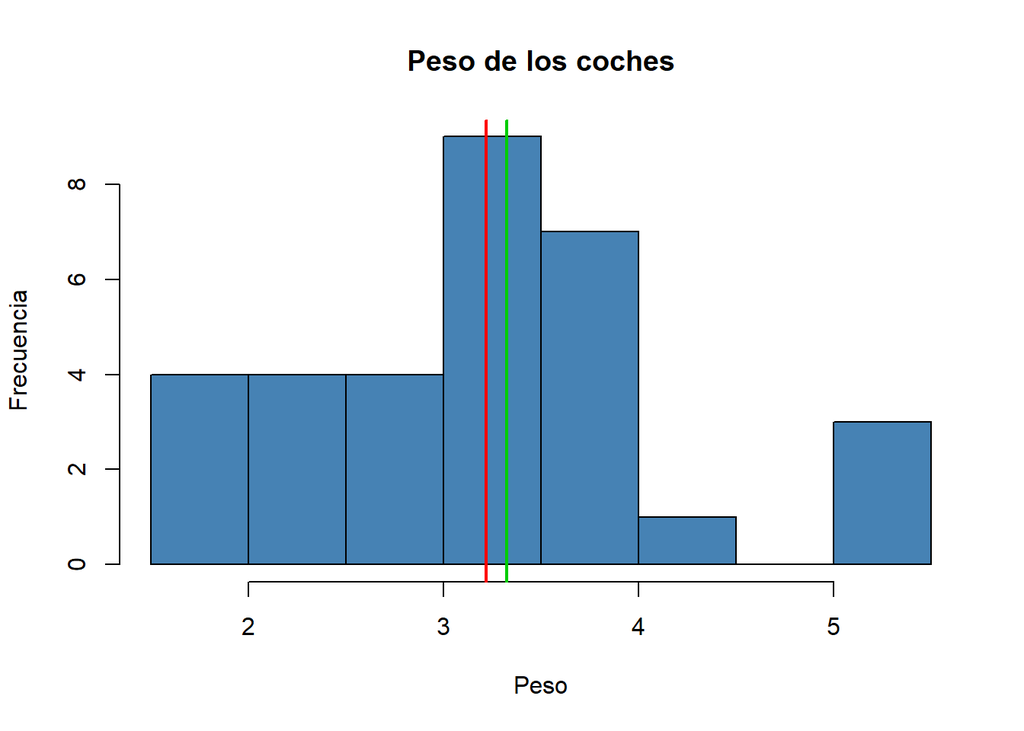

```r
hist(df$wt, main = "Peso de los coches", xlab = "Peso", ylab = "Frecuencia", col = "steelblue")
abline(v = mean(df$wt), col="red", lwd=2)
abline(v =median(df$wt),col="green3", lwd=2)
```

11.Cree un gráfico que muestre la relación entre el peso y las millas por galón: mpg en función de wt. Interprete el gráfico.

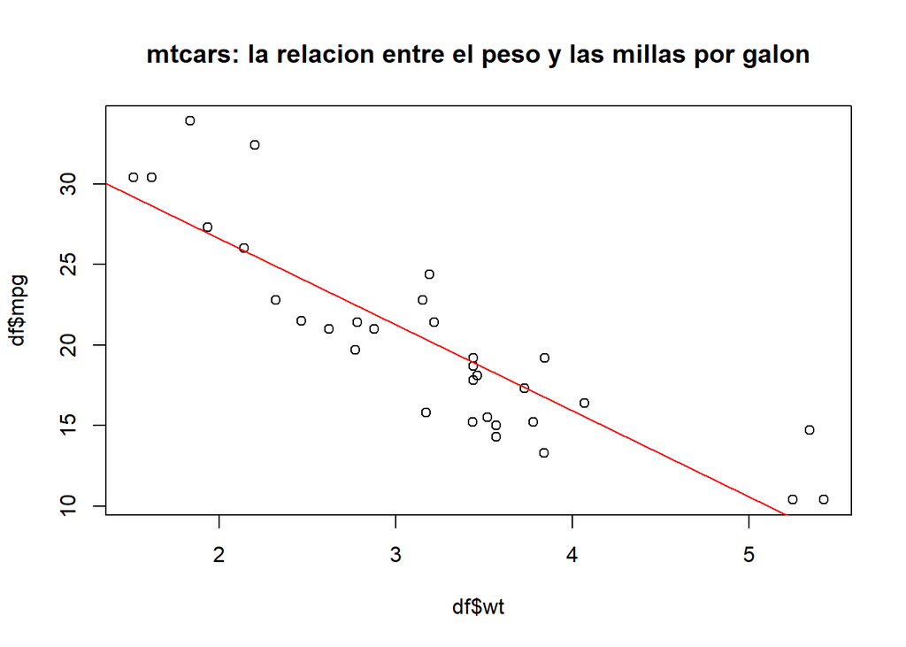

```r
plot(df$wt,df$mpg, main="mtcars: la relación entre el peso y las millas por galón")
abline(lm(df$mpg~df$wt), col="red")
```

Con base en el gráfico obtenido, podemos concluir que existe una relación inversa entre el peso y las millas por galón.

12.Convierta la variable cyl en un factor. A continuación, cree un diagrama de caja que represente los caballos de fuerza en función del número de cilindros. Interprete el gráfico.

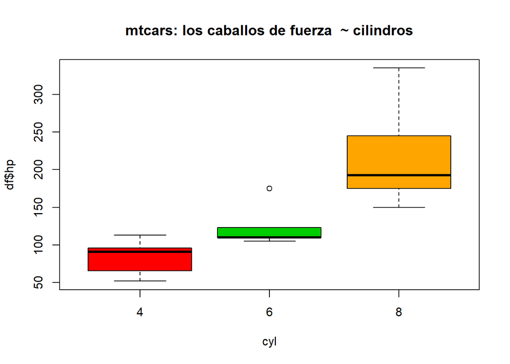

```r
cyl<-as.factor(df$cyl)
boxplot(df$hp ~ cyl, col = c("red","green3","orange"), main = "mtcars: los caballos de fuerza  ~ cilindros")
```